# Part I - Airline Delays and Cancellations Causes and Statistics

## Introduction

The complete data set consists of flight arrival and departure details for all commercial flights within the USA, from October 1987 to April 2008.  
As the original dataset is ~120MM records and for the purposes of the analysis, this analysis will be limited to 3 years (1988,1998, and 2008).  
The choice of the years considered a systematic sample where an interval of 10 years was chosen to represent the population.  
The data was downloaded from the American Statistical Association from [here](http://ww2.amstat.org/sections/graphics/datasets/DataExpo2009.zip)  
where the original data set is collected by The data is collected by the Office of Airline Information, Bureau of Transportation Statistics (BTS), United States Department of Transportation. The original data set can be found [here](https://www.transtats.bts.gov/DatabaseInfo.asp?QO_VQ=EFD&Yv0x=D)  
The chosen sample contains 17,596,545 rows and represents ~ 15% of the total available data set with 29 columns explained in the below table:

| Column Number | Variable Name | Variable Description |
| --- | --- | --- |
| 1 | Year | 1988-1998-2008 |
| 2 | Month | 1-12 |
| 3 | DayofMonth | 1-31 |
| 4 | DayOfWeek | 1 (Monday) - 7 (Sunday) |
| 5 | DepTime | actual departure time (local, hhmm) |
| 6 | CRSDepTime | scheduled departure time (local, hhmm) |
| 7 | ArrTime | actual arrival time (local, hhmm) |
| 8 | CRSArrTime | scheduled arrival time (local, hhmm) |
| 9 | UniqueCarrier | unique carrier code |
| 10 | FlightNum | flight number |
| 11 | TailNum | plane tail number |
| 12 | ActualElapsedTime | in minutes |
| 13 | CRSElapsedTime | in minutes |
| 14 | AirTime | in minutes |
| 15 | ArrDelay | arrival delay, in minutes |
| 16 | DepDelay | departure delay, in minutes |
| 17 | Origin | origin IATA airport code |
| 18 | Dest | destination IATA airport code |
| 19 | Distance | in miles |
| 20 | TaxiIn | taxi in time, in minutes |
| 21 | TaxiOut | taxi out time in minutes |
| 22 | Cancelled | was the flight cancelled? |
| 23 | CancellationCode | reason for cancellation (A = carrier, B = weather, C = NAS, D = security) |
| 24 | Diverted | 1 = yes, 0 = no |
| 25 | CarrierDelay | in minutes |
| 26 | WeatherDelay | in minutes |
| 27 | NASDelay | in minutes |
| 28 | SecurityDelay | in minutes |
| 29 | LateAircraftDelay | in minutes |

The aim of this study is to better understand the attributes contributing to delays and cancellations of flights. for the purposes of this study a flight is considered delayed when it is 15 minutes later than its scheduled time and cancellation occurs when the airline does not operate the flight at all for a certain reason as per the The Federal Aviation Administration (FAA), details can be found [here](https://en.wikipedia.org/wiki/Flight_cancellation_and_delay)

The sample dataset was further reduced into a subset that captures delays equal to or greater than 15 minutes and cancelled flights generating 4,400,236 rows and 29 columns for the analysis. This subset was saved as 'd_c_flights.csv'

## Preliminary Wrangling

```python
#update workspace seaborn version
import sys
!{sys.executable} -m pip install seaborn==0.11.2;
```

```python
#import all packages and set plots to be embedded inline
import numpy as np
import pandas as pd
import matplotlib.pyplot as plt
import seaborn as sns
from scipy import stats
from IPython.display import display
%matplotlib inline
```

> **NB:** *Code below will be commented out pre submission in order to prevent running as the original files will be* *removed from the project folder in order to allow submission and meet the required size limits*

```python
#load the data file for the year 1988

# df_1988 = pd.read_csv('1988.csv')
```

```python
#create year 1998 subset file

# df_1988_clean = df_1988.query('ArrDelay >= 15 or DepDelay >=15 or Cancelled == 1')
```

```python
#load the data file for the year 1998

# df_1998 = pd.read_csv('1998.csv')
```

```python
#create year 1998 subset file

# df_1998_clean = df_1998.query('ArrDelay >= 15 or DepDelay >=15 or Cancelled == 1')
```

```python
#load the data file for the year 2008

# df_2008 = pd.read_csv('2008.csv')
```

```python
#create year 2008 subset file

# df_2008_clean = df_2008.query('ArrDelay >= 15 or DepDelay >=15 or Cancelled == 1')
```

```python
#create combined data frame for delayed and cancelled flights for the years 1988, 1998, and 2008

# flights = df_1988_clean.append(df_1998_clean, ignore_index=True)
# flights = flights.append(df_2008_clean, ignore_index=True)
```

```python
#export clean dataframe to csv for later use

# flights.to_csv('d_c_flights.csv',index = False)
```

> **End of commented code .. files 1988.csv, 1998.csv and 2008.csv are deleted from project folder and d_c_flights.csv will be used going forward**

```python
#load subset file for analysis
flights = pd.read_csv('d_c_flights.csv', low_memory=False)
```

```python
#subset shape
flights.shape
```

```
(4400236, 29)
```

```python
#subset info
flights.info()
```

```
<class 'pandas.core.frame.DataFrame'>
RangeIndex: 4400236 entries, 0 to 4400235
Data columns (total 29 columns):
Year                 int64
Month                int64
DayofMonth           int64
DayOfWeek            int64
DepTime              float64
CRSDepTime           int64
ArrTime              float64
CRSArrTime           int64
UniqueCarrier        object
FlightNum            int64
TailNum              object
ActualElapsedTime    float64
CRSElapsedTime       float64
AirTime              float64
ArrDelay             float64
DepDelay             float64
Origin               object
Dest                 object
Distance             float64
TaxiIn               float64
TaxiOut              float64
Cancelled            int64
CancellationCode     object
Diverted             int64
CarrierDelay         float64
WeatherDelay         float64
NASDelay             float64
SecurityDelay        float64
LateAircraftDelay    float64
dtypes: float64(15), int64(9), object(5)
memory usage: 973.6+ MB
```

```python
#update NaN time values in variables of interest to 0

flights['AirTime'] = flights['AirTime'].fillna(0)
flights['DepDelay']= flights['DepDelay'].fillna(0)
flights['ArrDelay'] = flights['ArrDelay'].fillna(0)
flights['TaxiIn'] = flights['TaxiIn'].fillna(0)
flights['TaxiOut'] = flights['TaxiOut'].fillna(0)
```

```python
#convert variable of interest to integers as the values are in minutes

flights['AirTime'] = flights['AirTime'].astype('Int64')
flights['DepDelay']= flights['DepDelay'].astype('Int64')
flights['ArrDelay'] = flights['ArrDelay'].astype('Int64')
flights['TaxiIn'] = flights['TaxiIn'].astype('Int64')
flights['TaxiOut'] = flights['TaxiOut'].astype('Int64')
```

```python
#convert scheduled departure and arrival times to hours only

flights['CRSDepTime'] = pd.to_datetime(flights.CRSDepTime, format='%H', exact=False).dt.hour
flights['CRSArrTime'] = pd.to_datetime(flights.CRSArrTime, format='%H', exact=False).dt.hour
```

## Univariate Exploration

```python
#define color palette

c_palette = sns.color_palette("colorblind",10)
```

#### What are the top 10 carriers in terms of delays or cancellations?

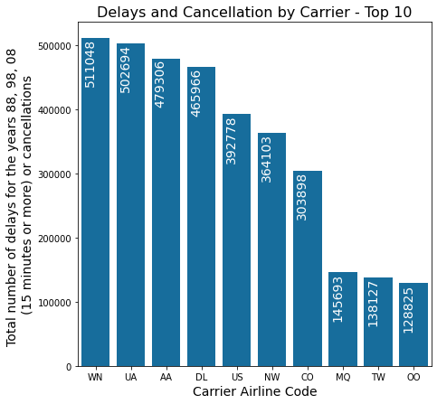

```python
#generate plot data

plt_data = flights['UniqueCarrier'].value_counts().head(10)
plt_order = plt_data.index

#adjust color

colors = c_palette[0]

#define plot

plt.subplots(figsize=(7,7))
plt.rcParams.update({'axes.xmargin': 0.5})
ax = sns.countplot(data=flights,x='UniqueCarrier',color = colors, order=plt_order)

#set title and axis

plt.title('Delays and Cancellation by Carrier - Top 10', fontsize=16);
plt.xlabel('Carrier Airline Code', fontsize=14);
plt.ylabel('Total number of delays for the years 88, 98, 08 \n(15 minutes or more) or cancellations',
           fontsize=14);

#add values to bars

for p in ax.patches:
   ax.annotate('{:}'.format(p.get_height()), (p.get_x()+0.25, p.get_height()+0.03), rotation = 90,
              color = 'white', horizontalalignment='center', verticalalignment='top',
              size=14)

#display plot

plt.show()
```

> Southwest seems to have suffered the largest numbers of delays with United Airlines, American Airlines, and Delta right after

#### What are the top 10 origin airports in terms of delays or cancellations?

```
ORD    299281
ATL    245201
DFW    192860
DEN    141108
EWR    136219
LAX    133608
DTW    133019
PHX    123987
SFO    123614
MSP    108763
Name: Origin, dtype: int64
```

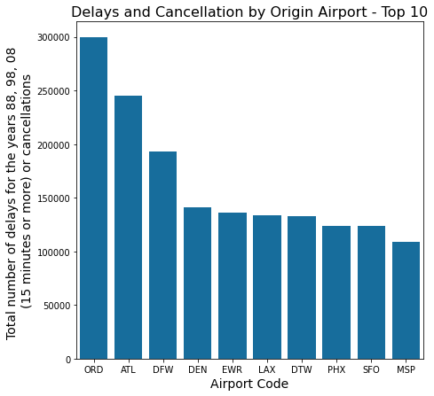

```python
#adjust color

colors = c_palette[0]

#generate plot data

plt_data = flights['Origin'].value_counts().head(10)
plt_order = plt_data.index

#define plot

fig, ax = plt.subplots(figsize=(7,7));
sns.countplot(data=flights,x='Origin',color=colors, order=plt_order)

#set title and axis

plt.title('Delays and Cancellation by Origin Airport - Top 10', fontsize=16);
plt.xlabel('Airport Code', fontsize=14);
plt.ylabel('Total number of delays for the years 88, 98, 08 \n(15 minutes or more) or cancellations',
           fontsize=14);
#display plot
print(plt_data);
plt.show();
```

#### What are the top 10 destination airports in terms of delays or cancellations?

```
ORD    273305
ATL    228642
DFW    156275
LAX    149178
SFO    141009
EWR    131698
DEN    129139
PHX    115622
DTW    106725
LGA    102572
Name: Dest, dtype: int64
```

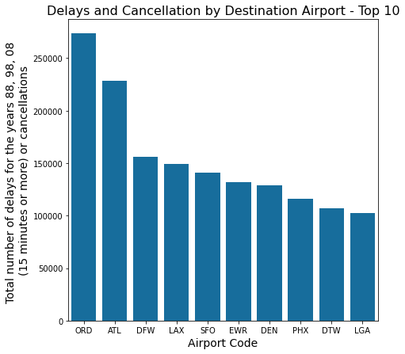

```python
#adjust color

colors = c_palette[0]

#generate plot data

plt_data = flights['Dest'].value_counts().head(10)
plt_order = plt_data.index

#define plot

fig, ax = plt.subplots(figsize=(7,7))
sns.countplot(data=flights,x='Dest',color=colors, order=plt_order)

#set title and axis

plt.title('Delays and Cancellation by Destination Airport - Top 10', fontsize=16);
plt.xlabel('Airport Code', fontsize=14);
plt.ylabel('Total number of delays for the years 88, 98, 08 \n(15 minutes or more) or cancellations',
           fontsize=14);

#display plot
print(plt_data);
plt.show();
```

#### Which day of the week experiences above average delays or cancellations?

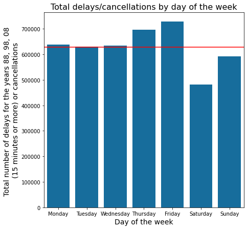

```python
#using the same code as the previous snippets did not run
#simplifying the dataframe for execution


#generate plot data

plt_data = flights['DayOfWeek'].value_counts()

#converting to df and assigning new names to the columns

df_weekday = pd.DataFrame(plt_data)
df_weekday = df_weekday.reset_index()
df_weekday.columns = ['weekday', 'total_delays'] # change column names

#adjust color

colors = c_palette[0]


#set plot size and type

fig, ax = plt.subplots(figsize=(7,7))
sns.barplot(data=df_weekday, x = 'weekday',y = 'total_delays',color=colors)

#set title and axis

week_day = ['Monday', 'Tuesday', 'Wednesday', 'Thursday', 'Friday', 'Saturday', 'Sunday']
ax.set_xticklabels(week_day)
plt.title('Total delays/cancellations by day of the week', fontsize=16);
plt.xlabel('Day of the week', fontsize=14);
plt.ylabel('Total number of delays for the years 88, 98, 08 \n(15 minutes or more) or cancellations',
           fontsize=14);

#plot mean line

plt.axhline(df_weekday.total_delays.mean(), c='red');
```

> Friday and Thursay show the most delays / cancellation, with Saturday the least

#### Which day of the month experiences the highest number of delays or cancellations?

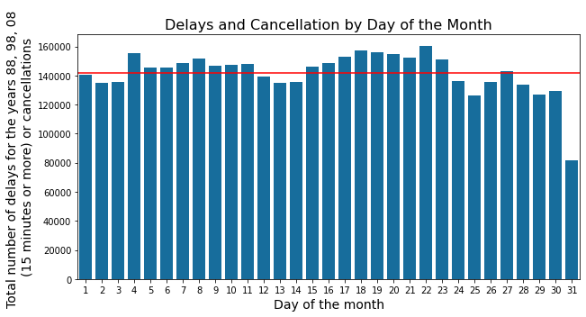

```python
#adjust color

colors = c_palette[0]

#generate plot dta

plt_data = flights['DayofMonth'].value_counts().sort_index(ascending=True)

#define plot

fig, ax = plt.subplots(figsize=(10,5))
sns.countplot(data=flights,x='DayofMonth',color=colors)

#set title and axis

plt.title('Delays and Cancellation by Day of the Month', fontsize=16);
plt.xlabel('Day of the month', fontsize=14);
plt.ylabel('Total number of delays for the years 88, 98, 08 \n(15 minutes or more) or cancellations',
           fontsize=14);

#plot mean line

plt.axhline(plt_data.mean(), c='red')

#display plot

plt.show()
```

> Day 22 of the month seems to be the most likely to suffer additional delays

#### Which month experiences the highest number of delays or cancellations?

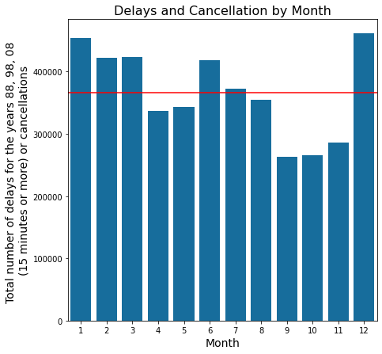

```python
#define plot color

colors = c_palette[0]

#generate plot data

plt_data = flights['Month'].value_counts().sort_index(ascending=True)
plt_order = plt_data.index

#define plot

fig, ax = plt.subplots(figsize=(7,7))
sns.countplot(data=flights,x='Month',color=colors, order=plt_order)

#set title and axis

plt.title('Delays and Cancellation by Month', fontsize=16);
plt.xlabel('Month', fontsize=14);
plt.ylabel('Total number of delays for the years 88, 98, 08 \n(15 minutes or more) or cancellations',
           fontsize=14);

#plot mean line

plt.axhline(plt_data.mean(), c='red')

#display plot

plt.show()
```

> December witnessed the most delays and cancellations with January coming second

#### What are the cancellation reasons?

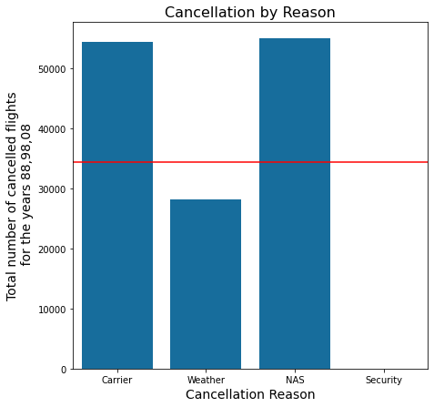

```python
#define plot color

colors = c_palette[0]

#generate plot data

plt_data = flights['CancellationCode'].value_counts().sort_index(ascending=True)

#define plot

fig, ax = plt.subplots(figsize=(7,7))
sns.countplot(data=flights,x='CancellationCode',color=colors)

#set title and axis

cancelled_code = ['Carrier', 'Weather', 'NAS', 'Security']
ax.set_xticklabels(cancelled_code)
plt.title('Cancellation by Reason', fontsize=16);
plt.xlabel('Cancellation Reason', fontsize=14);
plt.ylabel('Total number of cancelled flights\n for the years 88,98,08', fontsize=14);

#plot mean line

plt.axhline(plt_data.mean(), c='red')

#display plot

plt.show()
```

> Cancellation by Carrier and National Aviation System (non-extreme weather conditions, airport operations, heavy traffic volume, and air traffic control) are the top two reasons for cancellations

#### Does scheduled departure time affect delays or cancellations?

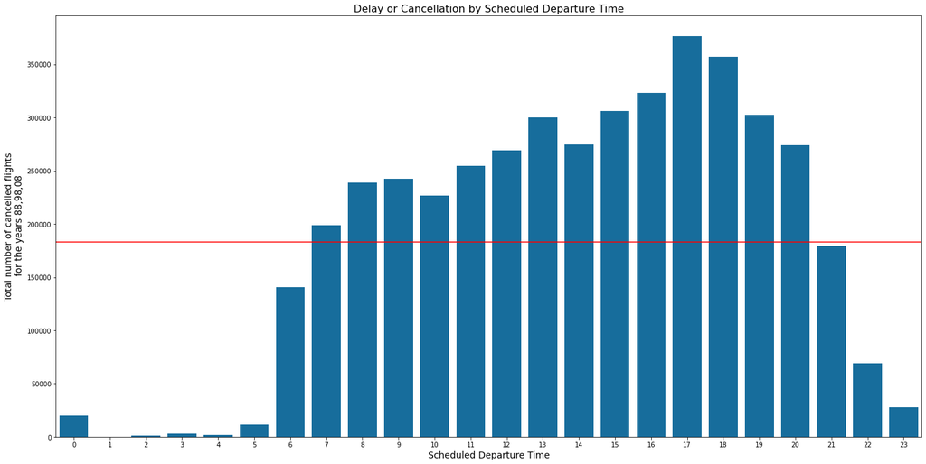

```python
#define plot color

colors = c_palette[0]

#generate plot data

plt_data = flights['CRSDepTime'].value_counts().sort_index(ascending=True)



#define plot

fig, ax = plt.subplots(figsize=(24,12))

sns.countplot(data=flights, x = 'CRSDepTime', color = colors)

#set title and axis

plt.title('Delay or Cancellation by Scheduled Departure Time', fontsize=16);
plt.xlabel('Scheduled Departure Time', fontsize=14);
plt.ylabel('Total number of cancelled flights\n for the years 88,98,08', fontsize=14);

#plot mean line

plt.axhline(plt_data.mean(), c='red')

#display plot

plt.show()
```

> plans departing 4 to 7 PM have suffered the most delays

#### Does scheduled arrival time affect delays or cancellations?

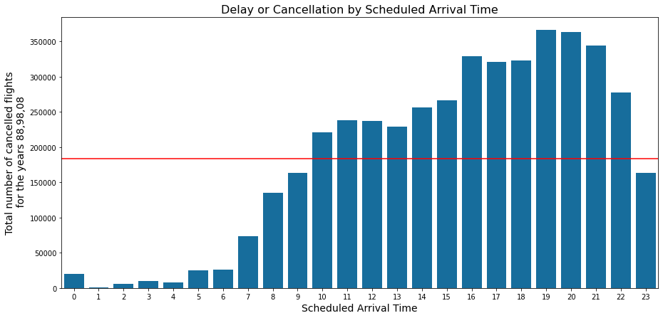

```python
#define plot color

colors = c_palette[0]

#generate plot data

plt_data = flights['CRSArrTime'].value_counts().sort_index(ascending=True)

#define plot

fig, ax = plt.subplots(figsize=(15,7))
sns.countplot(data = flights, x = 'CRSArrTime',color=colors)

#set title and axis

plt.title('Delay or Cancellation by Scheduled Arrival Time', fontsize=16);
plt.xlabel('Scheduled Arrival Time', fontsize=14);
plt.ylabel('Total number of cancelled flights\n for the years 88,98,08', fontsize=14);

#plot mean line

plt.axhline(plt_data.mean(), c='red')

#display plot

plt.show()
```

> plans arriving 7 to 9 PM have suffered the most delays

#### How does air time affect delays?

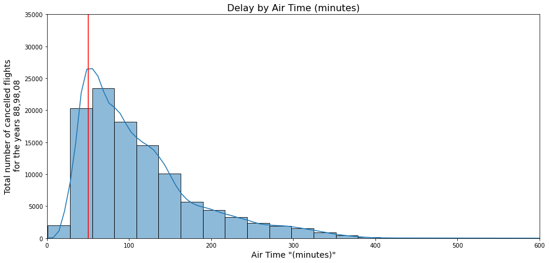

```python
#set plot color

colors = c_palette[0]

#generate plot data

plt_data = flights[(flights['Cancelled']== 0) & (flights['AirTime']> 0)]

#define plot

fig, ax = plt.subplots(figsize=(15,7))
sns.histplot(data=plt_data,x = 'AirTime', bins=50, kde=True, stat = "frequency")

#set title and axis

plt.title('Delay by Air Time (minutes)', fontsize=16);
plt.xlabel('Air Time "(minutes)"', fontsize=14);
plt.ylabel('Total number of cancelled flights\n for the years 88,98,08', fontsize=14);
plt.axis([0,600, 0, 35000])

#plot mean line

plt.axvline(50, c='red')

#display plot

plt.show()
```

#### What are the top 10 planes (by tail number) experiencing recurring delays or cancellations?

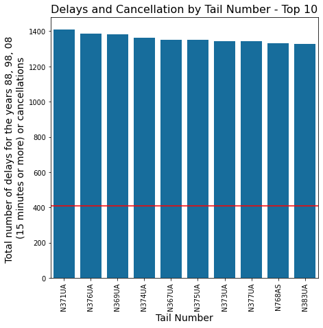

```python
#adjust color

colors = c_palette[0]

#generate plot data excluding missing tail numbers

plt_data = flights[(flights['TailNum'] != "UNKNOW")]['TailNum'].value_counts()
plt_order = plt_data.index

#convert dataframe and assign new names to the columns

df_tailnos = pd.DataFrame(plt_data.head(10))
df_tailnos = df_tailnos.reset_index()
df_tailnos.columns = ['TailNum', 'total_delays'] # change column names
df_tailnos


#define plot

fig, ax = plt.subplots(figsize=(7,7))
sns.barplot(data=df_tailnos, x = 'TailNum',y = 'total_delays',color=colors)

#set title and axis

plt.title('Delays and Cancellation by Tail Number - Top 10', fontsize=16);
plt.xlabel('Tail Number', fontsize=14);
plt.ylabel('Total number of delays for the years 88, 98, 08 \n(15 minutes or more) or cancellations',
           fontsize=14);
plt.xticks(rotation=90)

#plot mean line

plt.axhline(plt_data.mean(), c='red')

#display plot

plt.show()
```

> Aeroplane N371UA has suffered 1000 delays and cancellations more than the data set average

#### What are the top 10 flight numbers affected by delays and cancellations?

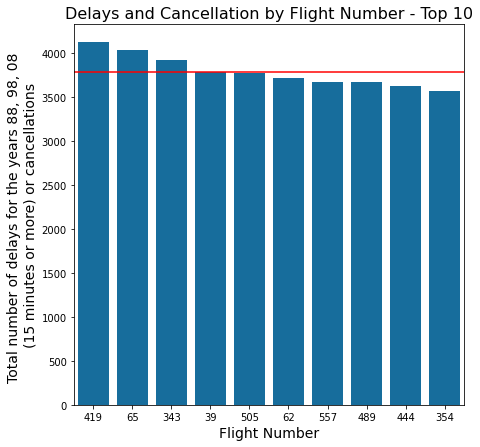

```python
#adjust color

colors = c_palette[0]

#generate plot data

plt_data = flights['FlightNum'].value_counts().head(10)
plt_order = plt_data.index

#define plot

fig, ax = plt.subplots(figsize=(7,7))
sns.countplot(data=flights,x='FlightNum',color = colors, order=plt_order)

#set title and axis

plt.title('Delays and Cancellation by Flight Number - Top 10', fontsize=16);
plt.xlabel('Flight Number', fontsize=14);
plt.ylabel('Total number of delays for the years 88, 98, 08 \n(15 minutes or more) or cancellations',
           fontsize=14);

#plot mean line

plt.axhline(plt_data.mean(), c='red')

#display plot

plt.show()
```

> Flight numbers 419, 65 and 343 are more prone to delays with above average delays during the study period

### Discuss the distribution(s) of your variable(s) of interest. Were there any unusual points? Did you need to perform any transformations?

> The study data set displayed multiple distribution types which is in line with the expected real life performance and the variables of interest

### Of the features you investigated, were there any unusual distributions? Did you perform any operations on the data to tidy, adjust, or change the form of the data? If so, why did you do this?

> No outliers were observed with the univariate exploration and no additional steps were required to tidy the data, as the set is a subset of the original data that is focused on cancellations and delays

## Bivariate Exploration

#### Do departure delays have an effect on arrival delays?

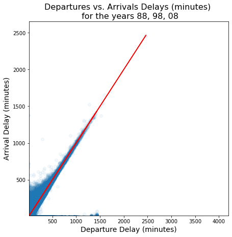

```
Pearson correlation coefficient:  0.8452848794503204
```

```python
#generate plot data

plt_data = flights[(flights['Cancelled']== 0) &
                   ((flights['DepDelay'] != 0) |
                   ( flights['ArrDelay']!=0))]

#generate plot

plt.figure(figsize=(7,7))
plt.scatter(data=plt_data,x='DepDelay',y='ArrDelay',alpha=1/20);

#calculate the trendline

fit = np.polyfit(plt_data['DepDelay'], plt_data['ArrDelay'], 1)
poly_line = np.poly1d(fit)

#print trend line

plt.plot(plt_data['DepDelay'],plt_data['DepDelay'],"r-");

#set title and axis

plt.title('Departures vs. Arrivals Delays (minutes) \n for the years 88, 98, 08', fontsize=16);
plt.xlabel('Departure Delay (minutes)', fontsize=14);
plt.ylabel('Arrival Delay (minutes)', fontsize=14);

#refocus axes to delay >= 15 minutes as pre definition

plt.xlim(14,);
plt.ylim(14,);

#show plot

plt.show();
print('Pearson correlation coefficient: ',stats.pearsonr(plt_data.DepDelay, plt_data.ArrDelay)[0]);
```

> a linear relationship is observed between departure delays and arrival delays as expected

#### How does air time impact arrival delay?

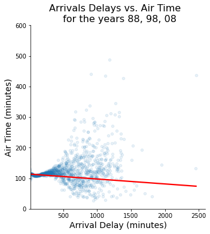

```
Pearson correlation coefficient:  -0.011816596169709242
```

```python
#generate plot data

plt_data = flights[(flights['AirTime'] !=0) & ( flights['ArrDelay']!= 0)
                   & (flights['Diverted']!=1) & (flights['Cancelled']!=1)]

#generate plot

plt.figure(figsize=(15,7));
ax = sns.lmplot(data=plt_data,x = 'ArrDelay',y = 'AirTime', ci=None, x_estimator=np.mean,
                scatter_kws={'s':20,'alpha':1/10}, line_kws={'color': 'red'});


#set title and axis

plt.title('Arrivals Delays vs. Air Time  \n for the years 88, 98, 08', fontsize=16);
plt.xlabel('Arrival Delay (minutes)', fontsize=14);
plt.ylabel('Air Time (minutes)', fontsize=14);

#refocus axes to delay >= 15 minutes as pre definition

plt.xlim(15,2600);
plt.ylim(0,600)

#show plot

plt.show();
print('Pearson correlation coefficient: ',stats.pearsonr(plt_data.ArrDelay, plt_data.AirTime)[0]);
```

> longer flights are able to recover a bit of the impact of departure delays

#### How does distance impact air time?

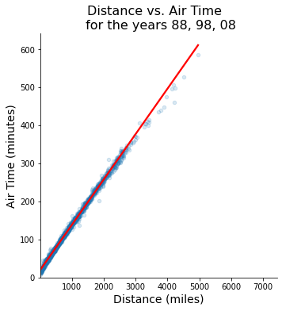

```
Pearson correlation coefficient:  0.9755326937617969
```

```python
#generate plot data

plt_data = flights[(flights['AirTime'] !=0)]

#generate plot

plt.figure(figsize=(7,7));
sns.lmplot(data=plt_data,x = 'Distance',y = 'AirTime',ci=None, x_estimator=np.mean,
                scatter_kws={'s':20,'alpha':1/6}, line_kws={'color': 'red'});

#set title and axis

plt.title('Distance vs. Air Time  \n for the years 88, 98, 08', fontsize=16);
plt.xlabel('Distance (miles)', fontsize=14);
plt.ylabel('Air Time (minutes)', fontsize=14);

#refocus view

plt.ylim(0,);
plt.xlim(15,);

#show plot

plt.show();
print('Pearson correlation coefficient: ',stats.pearsonr(plt_data.Distance, plt_data.AirTime)[0]);
```

> As expected Airtime is directly propotional with distance, outliers between 2000 and 3000 miles require further investigation

#### Do delayed flights get taxi out preference?

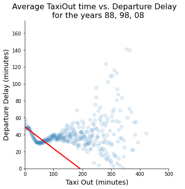

```
Pearson correlation coefficient:  -0.07883111953631083
```

```python
#generate plot data

plt_data = flights[(flights['Cancelled']== 0) & (flights['TaxiOut'] != 0)
                   & (flights['DepDelay']!= 0)][['TaxiOut','DepDelay']]

#generate plot

plt.figure(figsize=(7,7));
sns.lmplot(data=plt_data,x = 'TaxiOut',y = 'DepDelay',ci=None, x_estimator=np.mean,
                scatter_kws={'alpha':1/8}, line_kws={'color': 'red'});

#set title and axis

plt.title('Average TaxiOut time vs. Departure Delay  \n for the years 88, 98, 08', fontsize=16);
plt.xlabel('Taxi Out (minutes)', fontsize=14);
plt.ylabel('Departure Delay (minutes)', fontsize=14);

#refocus axes

plt.xlim(0,500);
plt.ylim(0,175);

#show plot

plt.show();
print('Pearson correlation coefficient: ',stats.pearsonr(plt_data.TaxiOut, plt_data.DepDelay)[0]);
```

> Delayed departures benefit from reduced Taxi Out timing

#### Do delayed flights get taxi in preference?

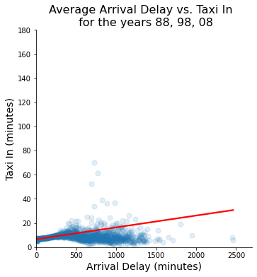

```
Pearson correlation coefficient:  0.07916142397004167
```

```python
#generate plot data

plt_data = flights[(flights['Cancelled']== 0) & (flights['TaxiIn'] != 0)
                   & (flights['ArrDelay']!= 0)][['TaxiIn','ArrDelay']]

#generate plot

plt.figure(figsize=(7,7));
sns.lmplot(data=plt_data,x = 'ArrDelay',y = 'TaxiIn',ci=None,  x_estimator=np.mean,
                scatter_kws={'alpha':1/8}, line_kws={'color': 'red'});

#set title and axis

plt.title('Average Arrival Delay vs. Taxi In  \n for the years 88, 98, 08', fontsize=16);
plt.xlabel('Arrival Delay (minutes)', fontsize=14);
plt.ylabel('Taxi In (minutes)', fontsize=14);

#refocus axes

plt.xlim(0,2700);
plt.ylim(0,180);

#show plot
plt.show();
print('Pearson correlation coefficient: ',stats.pearsonr(plt_data.ArrDelay, plt_data.TaxiIn)[0])
```

> delayed arrivals do not get any taxi benefits

### Talk about some of the relationships you observed in this part of the investigation. How did the feature(s) of interest vary with other features in the dataset?

> Delays compound, however, different behaviour was observed with airports Taxi in / Taxi out, with delayed departures seeming to get an advantage to taxi out whilst delayed arrivals were appear to be pushed down the landing queue at the arriving airport

### Did you observe any interesting relationships between the other features (not the main feature(s) of interest)?

> Airtime seems to provide an opportunity for delayed departures to reduce the delays

## Multivariate Exploration

#### Which day and which month experience the highest average of delays?

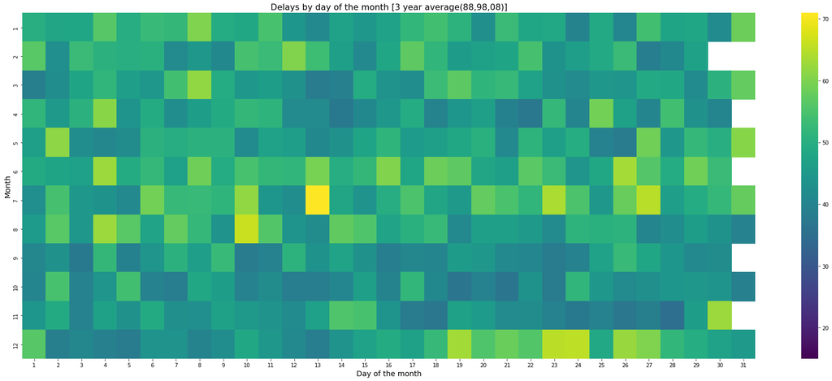

```python
#generate plot data

plt_data = flights[(flights['Cancelled']== 0) &
                   ((flights['DepDelay'] != 0) |
                   ( flights['ArrDelay']!=0))]

#pivot variables of interest

df = plt_data[['Month','DayofMonth','DepDelay','ArrDelay']].copy()
df['delay'] = plt_data.loc[:, ['DepDelay','ArrDelay']].max(axis=1)
pivot = df.pivot_table(index = 'Month', columns = 'DayofMonth',values='delay', aggfunc='mean')

#generate plot

plt.figure(figsize=(31,12));
sns.heatmap(pivot, vmin=15,cmap='viridis');

#set title and axis

plt.title('Delays by day of the month [3 year average(88,98,08)]', fontsize=16);
plt.xlabel('Day of the month', fontsize=14);
plt.ylabel('Month', fontsize=14);
```

> July 13 has the highest Average of Delays

#### Which day of the week and in which month does a traveller experience the highest average delays?

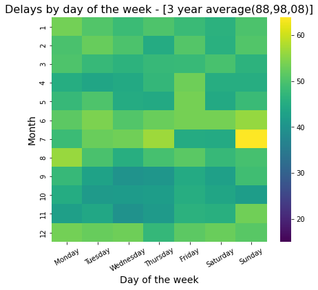

```python
#generate plot data

plt_data = flights[(flights['Cancelled']== 0) &
                   ((flights['DepDelay'] != 0) |
                   ( flights['ArrDelay']!=0))]

#generate plot pivot table

df = plt_data[['Month','DayOfWeek','DepDelay','ArrDelay']].copy()
df['delay'] = plt_data.loc[:, ['DepDelay','ArrDelay']].max(axis=1)
pivot = df.pivot_table(index = 'Month', columns = 'DayOfWeek',values='delay', aggfunc='mean')

#generate plot

plt.figure(figsize=(7,6));
ax = sns.heatmap(pivot, vmin = 15,cmap='viridis');

#set title and axis
week_day = ['Monday', 'Tuesday', 'Wednesday', 'Thursday', 'Friday', 'Saturday', 'Sunday']
ax.set_xticklabels(week_day, rotation=30)
plt.title('Delays by day of the week - [3 year average(88,98,08)]', fontsize=16);
plt.xlabel('Day of the week', fontsize=14);
plt.ylabel('Month', fontsize=14);
```

> July Sunday's are most likely to suffer the longest delays

#### Which day of the month can we expect the maximum number of cancellations?

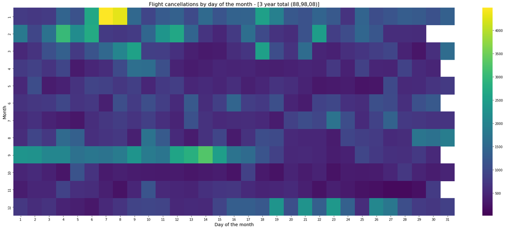

```python
#generate plot data

plt_data = flights[(flights['Cancelled']== 1)]

#generate plot pivot

df = plt_data[['Month','DayofMonth','Cancelled']].copy()
pivot = df.pivot_table(index = 'Month', columns = 'DayofMonth',values='Cancelled', aggfunc='sum')

#generate plot

plt.figure(figsize=(31,12));
sns.heatmap(pivot, vmin=15,cmap='viridis');

#set title and axis

plt.title('Flight cancellations by day of the month - [3 year total (88,98,08)]', fontsize=16);
plt.xlabel('Day of the month', fontsize=14);
plt.ylabel('Month', fontsize=14);
```

#### Which day of the week has the most cancellations?

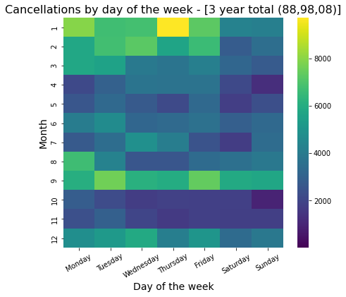

```python
#generate plot data

plt_data = flights[(flights['Cancelled']== 1)]

#generate plot pivot

df = plt_data[['Month','DayOfWeek','Cancelled']].copy()
pivot = df.pivot_table(index = 'Month', columns = 'DayOfWeek',values='Cancelled', aggfunc='sum')
plt.figure(figsize=(7,6));
ax = sns.heatmap(pivot, vmin = 15,cmap='viridis');

#set title and axis
week_day = ['Monday', 'Tuesday', 'Wednesday', 'Thursday', 'Friday', 'Saturday', 'Sunday']
ax.set_xticklabels(week_day, rotation=30)
plt.title('Cancellations by day of the week - [3 year total (88,98,08)]', fontsize=16);
plt.xlabel('Day of the week', fontsize=14);
plt.ylabel('Month', fontsize=14);
```

> Thursday's in January have the most cancellations over the period

#### What is the travel window in hours impacted the most with delays or cancellations and does the month of the year influence that window ?

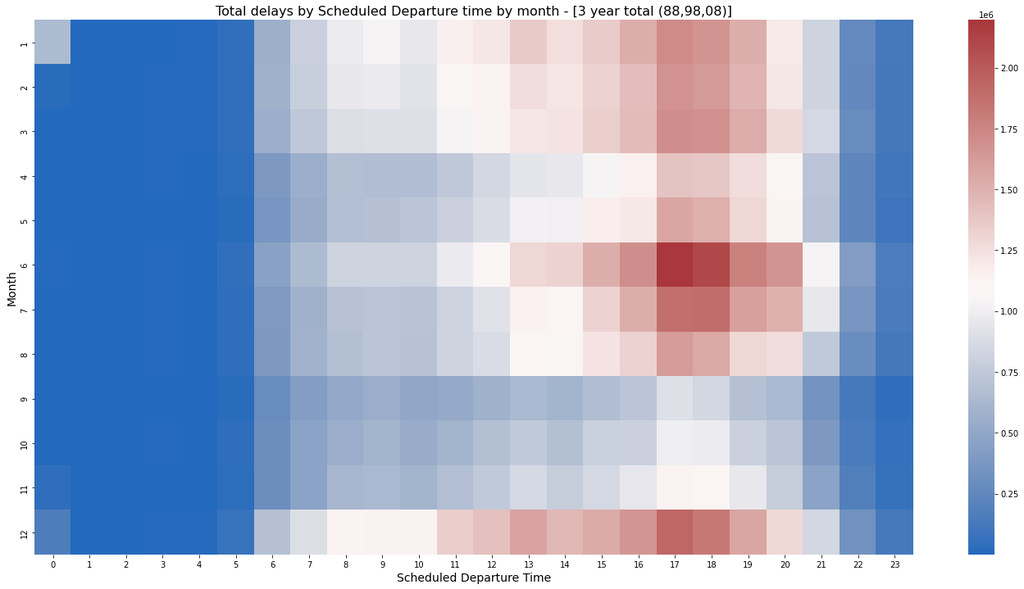

```python
#generate plot data

plt_data = flights[(((flights['DepDelay'] != 0)|( flights['ArrDelay']!=0)))]

#generate plot pivot

df = plt_data[['Month','CRSDepTime','DepDelay','ArrDelay']].copy()
df['delay']= plt_data.loc[:, ['DepDelay','ArrDelay']].max(axis=1)
pivot = df.pivot_table(index = 'Month', columns = 'CRSDepTime',values='delay', aggfunc='sum')

#generate plot

plt.figure(figsize=(24,12));
ax = sns.heatmap(pivot, cmap='vlag');

#set title and axis
plt.title('Total delays by Scheduled Departure time by month - [3 year total (88,98,08)]', fontsize=16);
plt.xlabel('Scheduled Departure Time', fontsize=14);
plt.ylabel('Month', fontsize=14);
```

> 16:00 to 19:00 appears to be the period being hit the hradest with delays

### Were there any interesting or surprising interactions between features?

> Thursdays in January suffer the most of cancellations

## Conclusions

Multiple delay and cancellation factors were explored. However, it is to be noted that the chosen subset only included delayed and cancelled flights and not the full flight data set due to system limitations, hence, the findings are limited to the study subset of cancelled and delayed flights and could present a biased view. The study subset is also assumed to represent and model the behaviour of over 3 decades of flying through the selection of the years 1988, 1998, and 2008 as a representative selective sample.